# Assignment 1

Derek Shat

9/20/2021

# Introduction

Gapminder is described in the [R Documentation](https://www.rdocumentation.org/packages/gapminder/versions/0.3.0/topics/gapminder) as “Excerpt of the Gapminder data on life expectancy, GDP per capita, and population by country”. It is a data frame containing 1704 rows and 6 variables: country, continent, year, life expectancy, population, and inflation-adjusted GDP per capita (in US dollars). There are 142 countries in the data, with data listed from 1952 to 2007 in increments of 5 years.

```r
# Load libraries
library(tidyverse)
library(knitr)

# Data
library(gapminder) # no functions, only data
data(gapminder)
```

# Variable Description

The identifiers in the data are the country, continent, and year variables. The metrics are life expectancy, population, and GDP per capita.

## Identifiers

```r
gapminder %>%
  summarise(countries = n_distinct(country),
            continents = n_distinct(continent),
            years = n_distinct(year)) %>%
  kable()
```

| countries | continents | years |
| --- | --- | --- |
| 142 | 5 | 12 |

The unique number of countries, continents, and years are 142, 5, and 12 respectively. The code below shows what these unique values are.

```r
unique(gapminder$country) #unique countries
```

```
##   [1] Afghanistan              Albania                  Algeria
##   [4] Angola                   Argentina                Australia
##   [7] Austria                  Bahrain                  Bangladesh
##  [10] Belgium                  Benin                    Bolivia
##  [13] Bosnia and Herzegovina   Botswana                 Brazil
##  [16] Bulgaria                 Burkina Faso             Burundi
##  [19] Cambodia                 Cameroon                 Canada
##  [22] Central African Republic Chad                     Chile
##  [25] China                    Colombia                 Comoros
##  [28] Congo, Dem. Rep.         Congo, Rep.              Costa Rica
##  [31] Cote d'Ivoire            Croatia                  Cuba
##  [34] Czech Republic           Denmark                  Djibouti
##  [37] Dominican Republic       Ecuador                  Egypt
##  [40] El Salvador              Equatorial Guinea        Eritrea
##  [43] Ethiopia                 Finland                  France
```

[output cut: 34 more lines]

```r
unique(gapminder$continent) #unique continents
```

```
## [1] Asia     Europe   Africa   Americas Oceania
## Levels: Africa Americas Asia Europe Oceania
```

```r
unique(gapminder$year) #unique years
```

```
##  [1] 1952 1957 1962 1967 1972 1977 1982 1987 1992 1997 2002 2007
```

```r
summary(gapminder %>% is.na()) #for missing (NA) values in general over the dataframe
```

```
##   country        continent          year          lifeExp
##  Mode :logical   Mode :logical   Mode :logical   Mode :logical
##  FALSE:1704      FALSE:1704      FALSE:1704      FALSE:1704
##     pop          gdpPercap
##  Mode :logical   Mode :logical
##  FALSE:1704      FALSE:1704
```

```r
#For missing or NaN values in the metrics
summary(gapminder$lifeExp %>% is.nan())
```

```
##    Mode   FALSE
## logical    1704
```

```r
summary(gapminder$pop %>% is.nan())
```

```
##    Mode   FALSE
## logical    1704
```

```r
summary(gapminder$gdpPercap %>% is.nan())
```

```
##    Mode   FALSE
## logical    1704
```

There are no missing values for any of the identifiers or metrics and none of them display NA or NaN values.

Identifiers should be analyzed as a group since they are interconnected and are related to each other. There is no observation without both the country and year. It could also be beneficial to analyze metrics between continents over the years by taking all of the observations and colouring them by continent to look for points of comparison such as growth over time.

## Metrics

### Life Expectation

```r
gapminder %>%
  summarise(min_lifeExp = min(lifeExp),
            q1_lifeExp = quantile(lifeExp,0.25),
            median_lifeExp = median(lifeExp),
            mean_lifeExp = mean(lifeExp),
            q3_lifeExp = quantile(lifeExp,0.75),
            max_lifeExp = max(lifeExp),
            sd_lifeExp = sd(lifeExp),
            IQR_lifeExp = IQR(lifeExp)) %>%
  kable()
```

| min_lifeExp | q1_lifeExp | median_lifeExp | mean_lifeExp | q3_lifeExp | max_lifeExp | sd_lifeExp | IQR_lifeExp |
| --- | --- | --- | --- | --- | --- | --- | --- |
| 23.599 | 48.198 | 60.7125 | 59.47444 | 70.8455 | 82.603 | 12.91711 | 22.6475 |

```r
gapminder %>%
  group_by(continent) %>%
  summarise(min_lifeExp = min(lifeExp),
            q1_lifeExp = quantile(lifeExp,0.25),
            median_lifeExp = median(lifeExp),
            mean_lifeExp = mean(lifeExp),
            q3_lifeExp = quantile(lifeExp,0.75),
            max_lifeExp = max(lifeExp),
            sd_lifeExp = sd(lifeExp),
            IQR_lifeExp = IQR(lifeExp)) %>%
  kable()
```

| continent | min_lifeExp | q1_lifeExp | median_lifeExp | mean_lifeExp | q3_lifeExp | max_lifeExp | sd_lifeExp | IQR_lifeExp |
| --- | --- | --- | --- | --- | --- | --- | --- | --- |
| Africa | 23.599 | 42.37250 | 47.7920 | 48.86533 | 54.41150 | 76.442 | 9.150210 | 12.0390 |
| Americas | 37.579 | 58.41000 | 67.0480 | 64.65874 | 71.69950 | 80.653 | 9.345088 | 13.2895 |
| Asia | 28.801 | 51.42625 | 61.7915 | 60.06490 | 69.50525 | 82.603 | 11.864532 | 18.0790 |
| Europe | 43.585 | 69.57000 | 72.2410 | 71.90369 | 75.45050 | 81.757 | 5.433178 | 5.8805 |
| Oceania | 69.120 | 71.20500 | 73.6650 | 74.32621 | 77.55250 | 81.235 | 3.795611 | 6.3475 |

There are several outliers when looking at each continent’s values. Africa has at least one outlier as maximum value since it lies above Q3 + 1.5*IQR, while Americas and Europe have outliers for their minimum values since they lie below Q1 - 1.5*IQR.

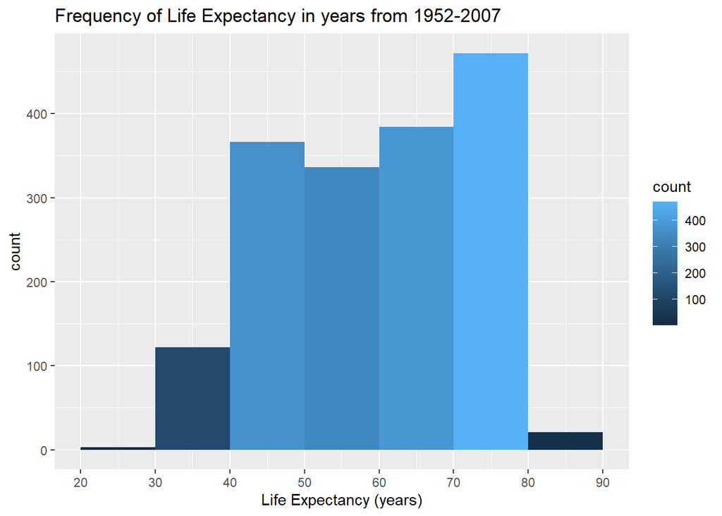

```r
gapminder %>% ggplot(aes(x = lifeExp, fill =..count..)) +
  scale_x_continuous(breaks = seq(0,100,10))+
  geom_histogram(breaks=c(20,30,40,50,60,70,80,90)) +
  labs(title = 'Frequency of Life Expectancy in years from 1952-2007',
       x = 'Life Expectancy (years)')
```

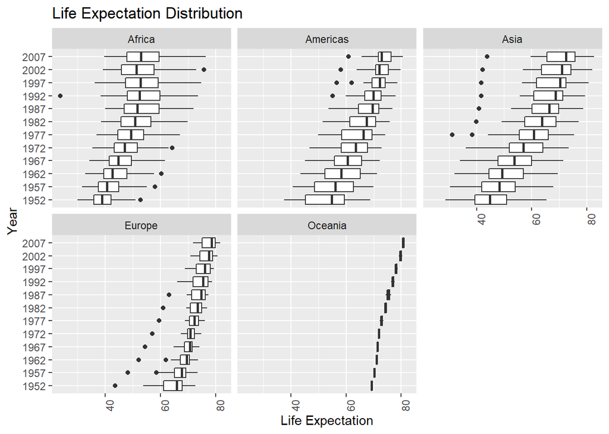

```r
gapminder %>%
  ggplot(aes(x = lifeExp, y = as_factor(year))) +
  geom_boxplot() +
  labs(title = 'Life Expectation Distribution',
       x = 'Life Expectation',
       y = 'Year') +
  facet_wrap(~continent, nrow = 2) +
  theme(axis.text.x = element_text(angle = 90))
```

All continents show a general trend of life expectation increasing upward, although to different degrees. Africa’s median life expectancy has stagnated since around 1982 and its interquartile range has increased over time. America’s interquartile range has decreased over time while life expectancy growth has slowed. In Asia and Europe, aside for some outliers on the lower end, life expectancy has mostly grown at the same rate, while Oceania’s life expectancy increase by larger amounts as time goes on.

### Population

```r
gapminder %>%
  summarise(min_pop = min(pop),
            q1_pop = quantile(pop,0.25),
            median_pop = median(pop),
            mean_pop = mean(pop),
            q3_pop = quantile(pop,0.75),
            max_pop = max(pop),
            sd_pop = sd(pop),
            IQR_pop = IQR(pop)) %>%
  kable()
```

| min_pop | q1_pop | median_pop | mean_pop | q3_pop | max_pop | sd_pop | IQR_pop |
| --- | --- | --- | --- | --- | --- | --- | --- |
| 60011 | 2793664 | 7023596 | 29601212 | 19585222 | 1318683096 | 106157897 | 16791558 |

```r
gapminder %>%
  group_by(continent) %>%
  summarise(min_pop = min(pop),
            q1_pop = quantile(pop,0.25),
            median_pop = median(pop),
            mean_pop = mean(pop),
            q3_pop = quantile(pop,0.75),
            max_pop = max(pop),
            sd_pop = sd(pop),
            IQR_pop = IQR(pop)) %>%
  kable()
```

| continent | min_pop | q1_pop | median_pop | mean_pop | q3_pop | max_pop | sd_pop | IQR_pop |
| --- | --- | --- | --- | --- | --- | --- | --- | --- |
| Africa | 60011 | 1342075 | 4579311 | 9916003 | 10801490 | 135031164 | 15490923 | 9459415 |
| Americas | 662850 | 2962359 | 6227510 | 24504795 | 18340309 | 301139947 | 50979430 | 15377950 |
| Asia | 120447 | 3844393 | 14530831 | 77038722 | 46300348 | 1318683096 | 206885205 | 42455955 |
| Europe | 147962 | 4331500 | 8551125 | 17169765 | 21802867 | 82400996 | 20519438 | 17471367 |
| Oceania | 1994794 | 3199213 | 6403492 | 8874672 | 14351625 | 20434176 | 6506342 | 11152413 |

There are also some outliers here. Africa, Americas, Asia, and Europe each have at least one outlier in the form of their maxes.

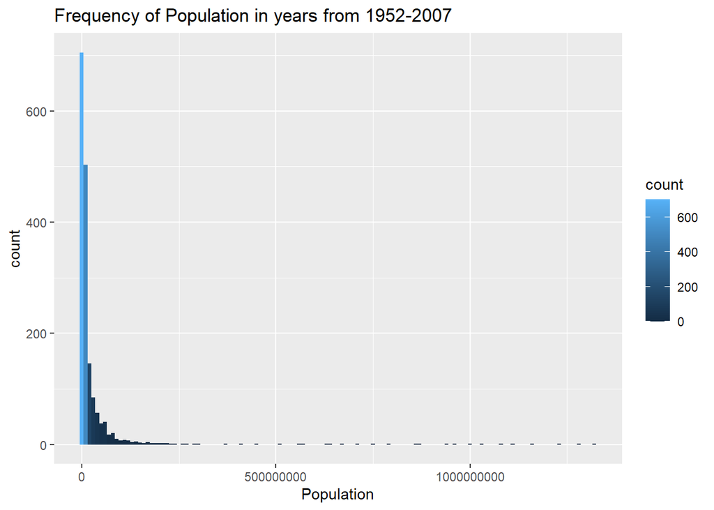

```r
options(scipen=999)
gapminder %>% ggplot(aes(x = pop, fill =..count..)) +
  geom_histogram(binwidth=10000000) +
  labs(title = 'Frequency of Population in years from 1952-2007',
       x = 'Population')
```

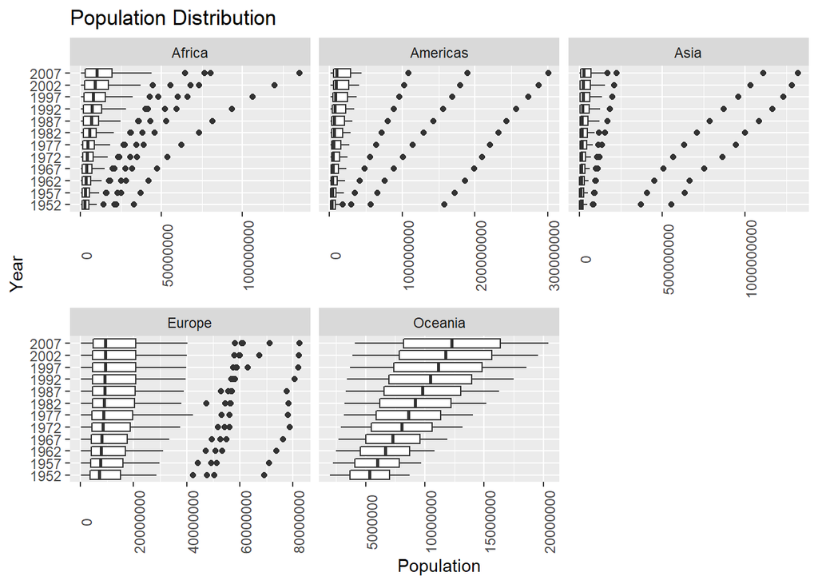

```r
options(scipen=999)
gapminder %>%
  ggplot(aes(x = pop, y = as_factor(year))) +
  geom_boxplot() +
  labs(title = 'Population Distribution',
       x = 'Population',
       y = 'Year') +
  facet_wrap(~continent, nrow = 2,scales="free_x") +
  theme(axis.text.x = element_text(angle = 90))
```

Since the outliers make it harder to discern trends for Americas and Asia, they will be taken out, and there will be separate graphs for just Asia as well as Africa, Americas, and Europe.

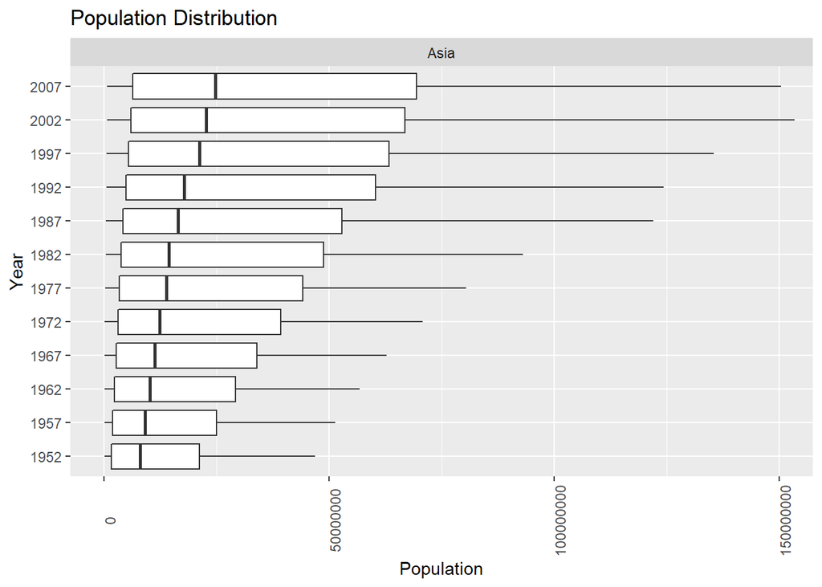

```r
options(scipen=999)
gapminder %>%
  filter(continent == "Asia") %>%
  ggplot(aes(x = pop, y = as_factor(year))) +
  geom_boxplot(outlier.shape=NA)+
  coord_cartesian(xlim = c(0,150000000)) +
  labs(title = 'Population Distribution',
       x = 'Population',
       y = 'Year') +
  facet_wrap(~continent, nrow = 2) +
  theme(axis.text.x = element_text(angle = 90))
```

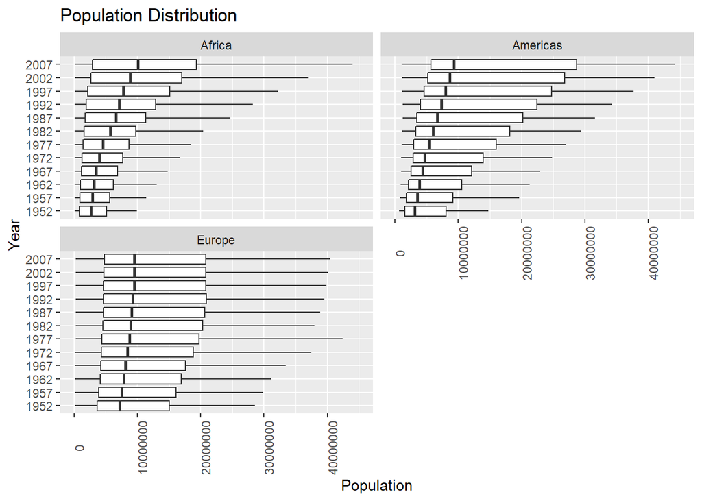

```r
gapminder %>%
  filter(continent == "Africa" | continent == "Americas" | continent == "Europe") %>%
  ggplot(aes(x = pop, y = as_factor(year))) +
  geom_boxplot(outlier.shape=NA)+
  coord_cartesian(xlim = c(0,45000000)) +
  labs(title = 'Population Distribution',
       x = 'Population',
       y = 'Year') +
  facet_wrap(~continent, nrow = 2) +
  theme(axis.text.x = element_text(angle = 90))
```

### GDP per capita

```r
gapminder %>%
  summarise(min_gdpPercap = min(gdpPercap),
            q1_lgdpPercap = quantile(gdpPercap,0.25),
            median_gdpPercap = median(gdpPercap),
            mean_gdpPercap = mean(gdpPercap),
            q3_gdpPercap = quantile(gdpPercap,0.75),
            max_gdpPercap = max(gdpPercap),
            sd_gdpPercap = sd(gdpPercap),
            IQR_gdpPercap = IQR(gdpPercap)) %>%
  kable()
```

| min_gdpPercap | q1_lgdpPercap | median_gdpPercap | mean_gdpPercap | q3_gdpPercap | max_gdpPercap | sd_gdpPercap | IQR_gdpPercap |
| --- | --- | --- | --- | --- | --- | --- | --- |
| 241.1659 | 1202.06 | 3531.847 | 7215.327 | 9325.462 | 113523.1 | 9857.455 | 8123.402 |

```r
gapminder %>%
  group_by(continent) %>%
  summarise(min_gdpPercap = min(gdpPercap),
            q1_gdpPercap = quantile(gdpPercap,0.25),
            median_gdpPercap = median(gdpPercap),
            mean_gdpPercap = mean(gdpPercap),
            q3_gdpPercap = quantile(gdpPercap,0.75),
            max_gdpPercap = max(gdpPercap),
            sd_gdpPercap = sd(gdpPercap),
            IQR_gdpPercap = IQR(gdpPercap)) %>%
  kable()
```

| continent | min_gdpPercap | q1_gdpPercap | median_gdpPercap | mean_gdpPercap | q3_gdpPercap | max_gdpPercap | sd_gdpPercap | IQR_gdpPercap |
| --- | --- | --- | --- | --- | --- | --- | --- | --- |
| Africa | 241.1659 | 761.247 | 1192.138 | 2193.755 | 2377.417 | 21951.21 | 2827.930 | 1616.170 |
| Americas | 1201.6372 | 3427.779 | 5465.510 | 7136.110 | 7830.210 | 42951.65 | 6396.764 | 4402.431 |
| Asia | 331.0000 | 1056.993 | 2646.787 | 7902.150 | 8549.256 | 113523.13 | 14045.373 | 7492.262 |
| Europe | 973.5332 | 7213.085 | 12081.749 | 14469.476 | 20461.386 | 49357.19 | 9355.213 | 13248.301 |
| Oceania | 10039.5956 | 14141.859 | 17983.304 | 18621.609 | 22214.117 | 34435.37 | 6358.983 | 8072.258 |

There are outliers here yet again. Each continent has outliers in the form of their maxes once again.

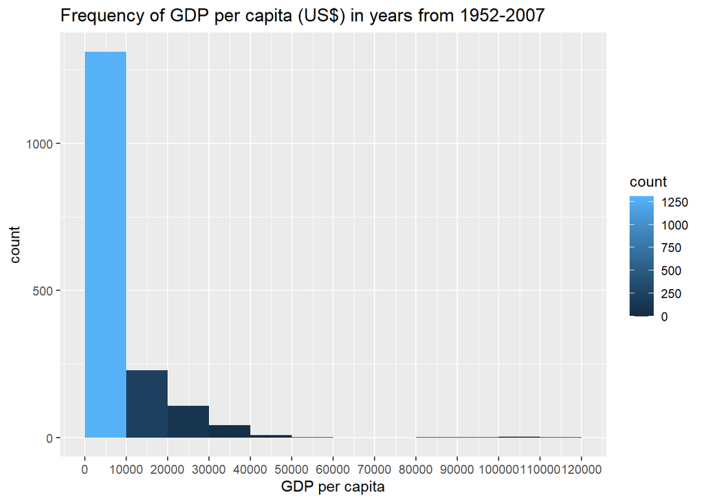

```r
options(scipen=999)
gapminder %>% ggplot(aes(x = gdpPercap, fill =..count..)) +
  scale_x_continuous(breaks = seq(0,120000,10000))+
  geom_histogram(breaks = c(0,10000,20000,30000,40000,50000,60000,70000,80000,90000,100000,110000,120000)) +
  labs(title = 'Frequency of GDP per capita (US$) in years from 1952-2007',
       x = 'GDP per capita')
```

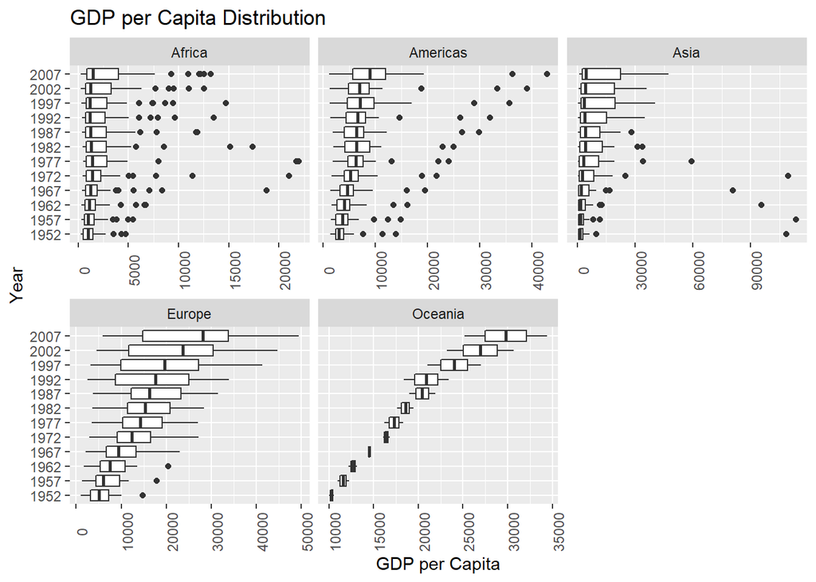

```r
gapminder %>%
  ggplot(aes(x = gdpPercap, y = as_factor(year))) +
  geom_boxplot() +
  labs(title = 'GDP per Capita Distribution',
       x = 'GDP per Capita',
       y = 'Year') +
  facet_wrap(~continent, nrow = 2,scales="free_x") +
  theme(axis.text.x = element_text(angle = 90))
```

For an alternate view that takes out outliers and focuses on Africa and Americas’ data since the other 3 are easier to see in the previous graphs…

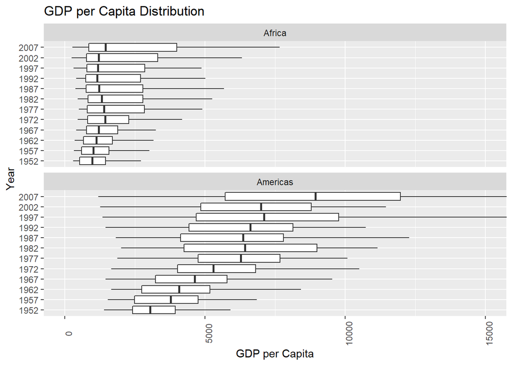

```r
gapminder %>%
  filter(continent == "Africa" | continent == "Americas") %>%
  ggplot(aes(x = gdpPercap, y = as_factor(year))) +
  geom_boxplot(outlier.shape = NA) +
  coord_cartesian(xlim = c(0,15000)) +
  labs(title = 'GDP per Capita Distribution',
       x = 'GDP per Capita',
       y = 'Year') +
  facet_wrap(~continent, nrow = 2) +
  theme(axis.text.x = element_text(angle = 90))
```

# Relationship between Life Expectancy and GDP per Capita

The linear correlation between life expectancy and GDP per capita:

```r
cor(gapminder$lifeExp,gapminder$gdpPercap)
```

```
## [1] 0.5837062
```

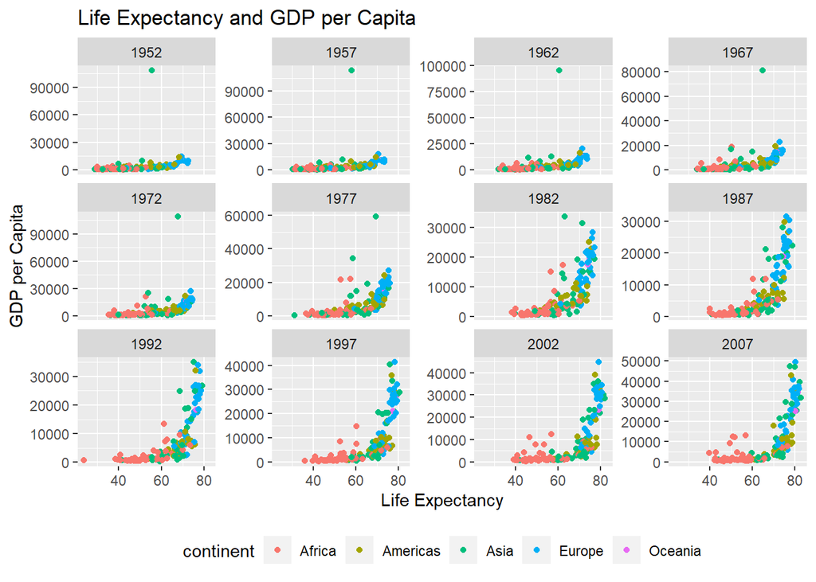

```r
gapminder %>%
  ggplot(aes(x = lifeExp, y = gdpPercap, color = continent)) +
  geom_point() +
  coord_cartesian()+
  labs(title = 'Life Expectancy and GDP per Capita',
       x = 'Life Expectancy',
       y = 'GDP per Capita') +
  facet_wrap(~year, nrow = 3,scales="free_y") +
  theme(legend.position='bottom')
```

# Conclusion

From this analysis, some questions to be asked are:

1. Are there any correlations between variables that seem to be stronger?
2. What metrics not in the Gapminder dataset seem likely to help explain the current metrics better?
3. Are there any major world events that may have affected the metrics in drastic ways? (e.g. Soviet dissolution on GDP per capita, changes in government)